# Part I - (Ford GoBike System Data Exploration and Visualization)

## Introduction

This data set includes information about individual rides made in a bike-sharing system covering the greater San Francisco Bay area. The aim of this project is to explore the dataset and ask important questions of the dataset such as which hour of the day has the most bikeshare rides and which age group uses the service most often.

## Preliminary Wrangling

```python
# import all packages and set plots to be embedded inline
import numpy as np
import pandas as pd
import matplotlib.pyplot as plt
import seaborn as sb

%matplotlib inline
```

## Gathering and Assesing Data

```python
#load in the dataset
bike = pd.read_csv('bike2.csv')
bike.head(5)
```

|  | duration_sec | start_time | end_time | start_station_id | start_station_name | start_station_latitude | start_station_longitude | end_station_id | end_station_name | end_station_latitude | end_station_longitude | bike_id | user_type | member_birth_year | member_gender | bike_share_for_all_trip |
| --- | --- | --- | --- | --- | --- | --- | --- | --- | --- | --- | --- | --- | --- | --- | --- | --- |
| 0 | 52185 | 2/28/19 17:32 | 3/1/19 8:01 | 21.0 | Montgomery St BART Station (Market St at 2nd St) | 37.789625 | -122.400811 | 13.0 | Commercial St at Montgomery St | 37.794231 | -122.402923 | 4902 | Customer | 1984.0 | Male | No |
| 1 | 42521 | 2/28/19 18:53 | 3/1/19 6:42 | 23.0 | The Embarcadero at Steuart St | 37.791464 | -122.391034 | 81.0 | Berry St at 4th St | 37.775880 | -122.393170 | 2535 | Customer | NaN | NaN | No |
| 2 | 61854 | 2/28/19 12:13 | 3/1/19 5:24 | 86.0 | Market St at Dolores St | 37.769305 | -122.426826 | 3.0 | Powell St BART Station (Market St at 4th St) | 37.786375 | -122.404904 | 5905 | Customer | 1972.0 | Male | No |
| 3 | 36490 | 2/28/19 17:54 | 3/1/19 4:02 | 375.0 | Grove St at Masonic Ave | 37.774836 | -122.446546 | 70.0 | Central Ave at Fell St | 37.773311 | -122.444293 | 6638 | Subscriber | 1989.0 | Other | No |
| 4 | 1585 | 2/28/19 23:54 | 3/1/19 0:20 | 7.0 | Frank H Ogawa Plaza | 37.804562 | -122.271738 | 222.0 | 10th Ave at E 15th St | 37.792714 | -122.248780 | 4898 | Subscriber | 1974.0 | Male | Yes |

```python
bike.tail(10)
```

|  | duration_sec | start_time | end_time | start_station_id | start_station_name | start_station_latitude | start_station_longitude | end_station_id | end_station_name | end_station_latitude | end_station_longitude | bike_id | user_type | member_birth_year | member_gender | bike_share_for_all_trip |
| --- | --- | --- | --- | --- | --- | --- | --- | --- | --- | --- | --- | --- | --- | --- | --- | --- |
| 183402 | 122 | 2/1/19 0:17 | 2/1/19 0:19 | 119.0 | 18th St at Noe St | 37.761047 | -122.432642 | 120.0 | Mission Dolores Park | 37.761420 | -122.426435 | 4326 | Subscriber | NaN | NaN | No |
| 183403 | 249 | 2/1/19 0:15 | 2/1/19 0:19 | 256.0 | Hearst Ave at Euclid Ave | 37.875112 | -122.260553 | 247.0 | Fulton St at Bancroft Way | 37.867789 | -122.265896 | 4642 | Subscriber | 2000.0 | Male | No |
| 183404 | 256 | 2/1/19 0:12 | 2/1/19 0:17 | 241.0 | Ashby BART Station | 37.852477 | -122.270213 | 248.0 | Telegraph Ave at Ashby Ave | 37.855956 | -122.259795 | 4845 | Subscriber | 1980.0 | Male | Yes |
| 183405 | 111 | 2/1/19 0:14 | 2/1/19 0:16 | 324.0 | Union Square (Powell St at Post St) | 37.788300 | -122.408531 | 19.0 | Post St at Kearny St | 37.788975 | -122.403452 | 4832 | Subscriber | 1984.0 | Male | No |
| 183406 | 706 | 2/1/19 0:04 | 2/1/19 0:16 | 138.0 | Jersey St at Church St | 37.750900 | -122.427411 | 78.0 | Folsom St at 9th St | 37.773717 | -122.411647 | 5017 | Subscriber | 1988.0 | Male | No |
| 183407 | 480 | 2/1/19 0:04 | 2/1/19 0:12 | 27.0 | Beale St at Harrison St | 37.788059 | -122.391865 | 324.0 | Union Square (Powell St at Post St) | 37.788300 | -122.408531 | 4832 | Subscriber | 1996.0 | Male | No |
| 183408 | 313 | 2/1/19 0:05 | 2/1/19 0:10 | 21.0 | Montgomery St BART Station (Market St at 2nd St) | 37.789625 | -122.400811 | 66.0 | 3rd St at Townsend St | 37.778742 | -122.392741 | 4960 | Subscriber | 1984.0 | Male | No |
| 183409 | 141 | 2/1/19 0:06 | 2/1/19 0:08 | 278.0 | The Alameda at Bush St | 37.331932 | -121.904888 | 277.0 | Morrison Ave at Julian St | 37.333658 | -121.908586 | 3824 | Subscriber | 1990.0 | Male | Yes |
| 183410 | 139 | 2/1/19 0:05 | 2/1/19 0:07 | 220.0 | San Pablo Ave at MLK Jr Way | 37.811351 | -122.273422 | 216.0 | San Pablo Ave at 27th St | 37.817827 | -122.275698 | 5095 | Subscriber | 1988.0 | Male | No |
| 183411 | 271 | 2/1/19 0:00 | 2/1/19 0:04 | 24.0 | Spear St at Folsom St | 37.789677 | -122.390428 | 37.0 | 2nd St at Folsom St | 37.785000 | -122.395936 | 1057 | Subscriber | 1989.0 | Male | No |

```python
#check the shape of the dataset
bike.shape
```

```
(183412, 16)
```

```python
#check the column information
bike.info()
```

```
<class 'pandas.core.frame.DataFrame'>
RangeIndex: 183412 entries, 0 to 183411
Data columns (total 16 columns):
duration_sec               183412 non-null int64
start_time                 183412 non-null object
end_time                   183412 non-null object
start_station_id           183215 non-null float64
start_station_name         183215 non-null object
start_station_latitude     183412 non-null float64
start_station_longitude    183412 non-null float64
end_station_id             183215 non-null float64
end_station_name           183215 non-null object
end_station_latitude       183412 non-null float64
end_station_longitude      183412 non-null float64
bike_id                    183412 non-null int64
user_type                  183412 non-null object
member_birth_year          175147 non-null float64
member_gender              175147 non-null object
bike_share_for_all_trip    183412 non-null object
dtypes: float64(7), int64(2), object(7)
memory usage: 22.4+ MB
```

```python
#check for missing values in the columns
bike.isnull().sum().sum()
```

```
17318
```

```python
#check for any duplicated rows in the dataset
bike.duplicated().sum()
```

```
0
```

```python
#check for the relevant statistics of the numerical columns
bike.describe()
```

|  | duration_sec | start_station_id | start_station_latitude | start_station_longitude | end_station_id | end_station_latitude | end_station_longitude | bike_id | member_birth_year |
| --- | --- | --- | --- | --- | --- | --- | --- | --- | --- |
| count | 183412.000000 | 183215.000000 | 183412.000000 | 183412.000000 | 183215.000000 | 183412.000000 | 183412.000000 | 183412.000000 | 175147.000000 |
| mean | 726.078435 | 138.590427 | 37.771223 | -122.352664 | 136.249123 | 37.771427 | -122.352250 | 4472.906375 | 1984.806437 |
| std | 1794.389780 | 111.778864 | 0.099581 | 0.117097 | 111.515131 | 0.099490 | 0.116673 | 1664.383394 | 10.116689 |
| min | 61.000000 | 3.000000 | 37.317298 | -122.453704 | 3.000000 | 37.317298 | -122.453704 | 11.000000 | 1878.000000 |
| 25% | 325.000000 | 47.000000 | 37.770083 | -122.412408 | 44.000000 | 37.770407 | -122.411726 | 3777.000000 | 1980.000000 |
| 50% | 514.000000 | 104.000000 | 37.780760 | -122.398285 | 100.000000 | 37.781010 | -122.398279 | 4958.000000 | 1987.000000 |
| 75% | 796.000000 | 239.000000 | 37.797280 | -122.286533 | 235.000000 | 37.797320 | -122.288045 | 5502.000000 | 1992.000000 |
| max | 85444.000000 | 398.000000 | 37.880222 | -121.874119 | 398.000000 | 37.880222 | -121.874119 | 6645.000000 | 2001.000000 |

## Cleaning the Data

```python
#making a copy of the data before cleaning
bike_clean = bike.copy()
```

```python
#dropping the null values
bike_clean = bike_clean.dropna()
```

```python
#checking for the new shape after the null records were dropped
bike_clean.shape
```

```
(174952, 16)
```

For the purpose of my analysis, i would be dropping some of the initial columns in the dataset and adding some new ones which i deem would be important for getting the best out of my analysis.

```python
#dropping unneeded columns for analysis
bike_clean = bike_clean.drop(['start_station_id','start_station_latitude','start_station_longitude','end_station_id',
                              'end_station_latitude','end_station_longitude','bike_id'],axis = 1)
```

```python
#checking new columns after dropping the unneeded columns
bike_clean.columns
```

```
Index(['duration_sec', 'start_time', 'end_time', 'start_station_name',
       'end_station_name', 'user_type', 'member_birth_year', 'member_gender',
       'bike_share_for_all_trip'],
      dtype='object')
```

```python
#coverting both the start_time and end_time columns to the correct datatype
bike_clean['start_time'] = pd.to_datetime(bike_clean['start_time'])
bike_clean['end_time'] = pd.to_datetime(bike_clean['end_time'])
```

```python
#checking to see if both time columns are of the correct datatype
bike_clean.info()
```

```
<class 'pandas.core.frame.DataFrame'>
Int64Index: 174952 entries, 0 to 183411
Data columns (total 9 columns):
duration_sec               174952 non-null int64
start_time                 174952 non-null datetime64[ns]
end_time                   174952 non-null datetime64[ns]
start_station_name         174952 non-null object
end_station_name           174952 non-null object
user_type                  174952 non-null object
member_birth_year          174952 non-null float64
member_gender              174952 non-null object
bike_share_for_all_trip    174952 non-null object
dtypes: datetime64[ns](2), float64(1), int64(1), object(5)
memory usage: 13.3+ MB
```

```python
#adding new columns to the dataset
bike_clean['duration_minute'] = bike_clean['duration_sec']/60
bike_clean['start_hourofday'] = bike_clean.start_time.dt.strftime('%H')
bike_clean['start_dayofweek'] = bike_clean.start_time.dt.strftime('%A')
bike_clean['start_dayofmonth'] = bike_clean.start_time.dt.strftime('%d')
```

```python
#checking to see the new columns
bike_clean.sample(5)
```

|  | duration_sec | start_time | end_time | start_station_name | end_station_name | user_type | member_birth_year | member_gender | bike_share_for_all_trip | duration_minute | start_hourofday | start_dayofweek | start_dayofmonth |
| --- | --- | --- | --- | --- | --- | --- | --- | --- | --- | --- | --- | --- | --- |
| 117055 | 327 | 2019-02-12 06:18:00 | 2019-02-12 06:24:00 | 5th St at Brannan St | Powell St BART Station (Market St at 4th St) | Subscriber | 1995.0 | Male | No | 5.450000 | 06 | Tuesday | 12 |
| 138539 | 324 | 2019-02-08 07:20:00 | 2019-02-08 07:25:00 | San Francisco Public Library (Grove St at Hyde... | McCoppin St at Valencia St | Subscriber | 1975.0 | Male | No | 5.400000 | 07 | Friday | 08 |
| 141800 | 752 | 2019-02-07 17:36:00 | 2019-02-07 17:49:00 | Golden Gate Ave at Franklin St | 16th St Mission BART Station 2 | Subscriber | 1989.0 | Male | No | 12.533333 | 17 | Thursday | 07 |
| 103293 | 399 | 2019-02-14 13:45:00 | 2019-02-14 13:52:00 | Pierce St at Haight St | Market St at 10th St | Subscriber | 1965.0 | Male | No | 6.650000 | 13 | Thursday | 14 |
| 149083 | 979 | 2019-02-06 19:52:00 | 2019-02-06 20:08:00 | Civic Center/UN Plaza BART Station (Market St ... | Central Ave at Fell St | Subscriber | 1994.0 | Male | No | 16.316667 | 19 | Wednesday | 06 |

```python
#changing the user_type,member_gender and bike_share_for_all_trip columns to category datatype and converting the
#member_birth_year to type integer
bike_clean['user_type']  = bike_clean['user_type'].astype('category')
bike_clean['member_gender']  = bike_clean['member_gender'].astype('category')
bike_clean['bike_share_for_all_trip']  = bike_clean['bike_share_for_all_trip'].astype('category')
bike_clean['member_birth_year'] = bike_clean['member_birth_year'].astype(int)
```

```python
#checking to see if the dataypes were correctly changed
bike_clean.info()
```

```
<class 'pandas.core.frame.DataFrame'>
Int64Index: 174952 entries, 0 to 183411
Data columns (total 13 columns):
duration_sec               174952 non-null int64
start_time                 174952 non-null datetime64[ns]
end_time                   174952 non-null datetime64[ns]
start_station_name         174952 non-null object
end_station_name           174952 non-null object
user_type                  174952 non-null category
member_birth_year          174952 non-null int64
member_gender              174952 non-null category
bike_share_for_all_trip    174952 non-null category
duration_minute            174952 non-null float64
start_hourofday            174952 non-null object
start_dayofweek            174952 non-null object
start_dayofmonth           174952 non-null object
dtypes: category(3), datetime64[ns](2), float64(1), int64(2), object(5)
memory usage: 15.2+ MB
```

```python
#creating the members age column by subtracting the member birth years from the year form which the dataset was recorded.
bike_clean['age'] = 2019 - bike_clean['member_birth_year']
```

```python
bike_clean.info()
```

```
<class 'pandas.core.frame.DataFrame'>
Int64Index: 174952 entries, 0 to 183411
Data columns (total 14 columns):
duration_sec               174952 non-null int64
start_time                 174952 non-null datetime64[ns]
end_time                   174952 non-null datetime64[ns]
start_station_name         174952 non-null object
end_station_name           174952 non-null object
user_type                  174952 non-null category
member_birth_year          174952 non-null int64
member_gender              174952 non-null category
bike_share_for_all_trip    174952 non-null category
duration_minute            174952 non-null float64
start_hourofday            174952 non-null object
start_dayofweek            174952 non-null object
start_dayofmonth           174952 non-null object
age                        174952 non-null int64
dtypes: category(3), datetime64[ns](2), float64(1), int64(3), object(5)
memory usage: 16.5+ MB
```

```python
#save dataframe to a csv file
bike_clean.to_csv('bike.csv',index = False)
```

### What is the structure of your dataset?

The initial dataset had 183,412 rows and 16 columns which contained information that can be split into three different categories

- Time : duration of the bike share ride(duration_sec), start time and end time of the bike share rides(start_time,end_time)
- Station: information about the stations(start_station_id, start_station_name, start_station_latitude, start_station_longitude, end_station_id, end_station_name, end_station_latitude, end_station_longitude)
- User : User information (bike_id,member_gender,member_birth_year,bike_share_for_all_trip).

> The main features of interest involves finding out the average trip duration, and how that relates to the user charcateristics such as the gender, age, user type and if people sharing the trip take longer or lesser trips.

### What features in the dataset do you think will help support your investigation into your feature(s) of interest?

> The columns related to the time will show us how longa trip takes and whem the trips are most commomly occuring, and the user columns will help us identify what the main customer groups are and if there are patterns associated with specific groups.

## Univariate Exploration

```python
color = sb.color_palette('colorblind')[0]
```

```python
# creating a function for countplots that have the ability for ordering
def countplot(x_axis, order, title, xlabel, ylabel):
    '''
    docstring: function to plt countplots
    input: x_axis, order,title,xlabel,ylabel
    output: plots a countplot with the x_axis plotted against the count of the x_axis, ordered by the order.
    The plot is titled with the the title, and the x and y axis are labelled wit the xlabel and ylabel respectively.
    '''
    #set background style
    sb.set_style('darkgrid')
    #set figure size
    plt.figure(figsize = [15,5])
    #set countplot bars colors
    color = sb.color_palette('colorblind')[0]
    #plot the chart
    sb.countplot(data = bike, x = x_axis, color = color, order = order)
    plt.title(title)
    plt.xlabel(xlabel)
    plt.ylabel(ylabel);
```

### Question : What is the trip distribution over each day of the month?

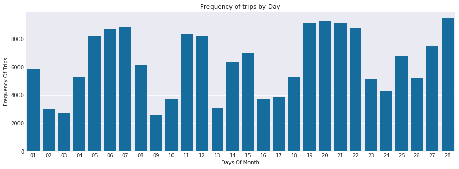

```python
#getting the order for the days
orderByDay = bike_clean.sort_values(by=['start_dayofmonth'],ascending = True)
orderByDay = orderByDay.groupby('start_dayofmonth').start_dayofmonth.count().index
countplot(bike_clean['start_dayofmonth'],orderByDay,"Frequency of trips by Day",'Days Of Month','Frequency Of Trips')
```

We can see from the distribution above that the day with the most trips ordered was the last day of the month. The distribution also generally follows a pattern the working days of the week having a higher frequency than the weeekeds. We can further investigate by looking at the distribution of the days in a week

### Question : What is the trip distribution over each day of the week?`

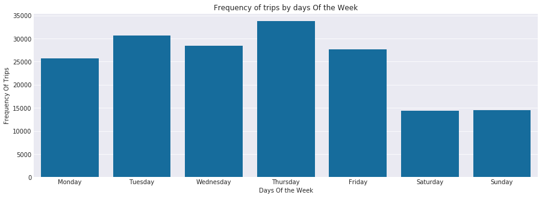

```python
#get order for days of the week
orderbyDayOfWeek = ['Monday','Tuesday','Wednesday','Thursday','Friday','Saturday','Sunday']
#plot the chart
countplot(bike_clean['start_dayofweek'],orderbyDayOfWeek,"Frequency of trips by days Of the Week",
          'Days Of the Week','Frequency Of Trips')
```

Our earlier hunch that weekdays have more trips than weekends is bolstered by the visualizations above which shows a downturn in the number of trips on the weekends. We can therefore guess that the trips are mostly for commuting to and from work. We can bolster this assumption by looking at the distribution of trips during the hours of the day.

### Question : What is the trip distribution over each hour of the day ?

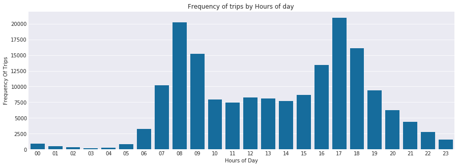

```python
#get order for each hour in the day
orderByHourOfDay = bike_clean.sort_values(by=['start_hourofday'])
orderByHourOfDay = orderByHourOfDay.groupby('start_hourofday').start_hourofday.count().index
# plot the chart
countplot(bike_clean['start_hourofday'],orderByHourOfDay,"Frequency of trips by Hours of day ",
          'Hours of Day','Frequency Of Trips')
```

The chart strengthens our earlier assumption by showing the hours with the most trips to be 08:00 and 17:00 hours which conicides with rush hour and the times people are likely headed to work and returning from work.

### Question : Which user type is more prevalent?

```python
# creating a function for unordered countplots
def countplots(data, x_axis, title, xlabel, ylabel):
    #set background style
    sb.set_style('darkgrid')
    #set figure size
    plt.figure(figsize = [15,5])
    #set countplot bars colors
    color = sb.color_palette('colorblind')[0]
    #plot the chart
    sb.countplot(data = data, x = x_axis, color = color)
    plt.title(title)
    plt.xlabel(xlabel)
    plt.ylabel(ylabel);
```

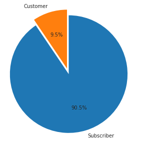

```python
plt.figure(figsize = [15,5])
sorted_vals = bike_clean.user_type.value_counts()/bike_clean.shape[0];
plt.pie(sorted_vals, explode=[0, 0.1], labels=sorted_vals.index, startangle=90, counterclock=False, autopct='%1.1f%%');
plt.axis('square');
```

From the above chart, we can see that the subcribers(members of the bike sharing service) are of a much greater proportion ths the customer(casual users of the bike sharing service).

### Question : Which gender is more prevalent?

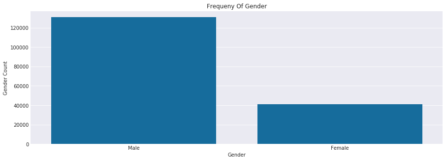

```python
#get for just the male and Female genders
gender = bike[bike['member_gender'].isin(['Male','Female'])]
countplots(gender,gender.member_gender,'Frequeny Of Gender','Gender', 'Gender Count')
```

There a lot more male members of the bike sharing service than there are female members.

### Are members sharing their bike rides?

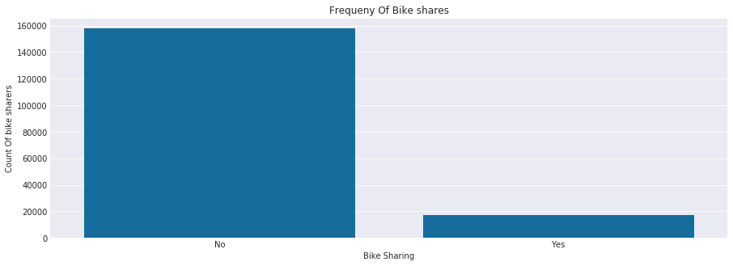

```python
countplots(bike_clean,bike_clean.bike_share_for_all_trip,'Frequeny Of Bike shares','Bike Sharing', 'Count Of bike sharers')
```

The majority of customers ride alone and do not utilise the bike sharing option

### Question : What age groups mostly use the bike sharing service?

We check for outliers both visually and programmatically in the age column.

```python
bike_clean.age.describe()
```

```
count    174952.000000
mean         34.196865
std          10.118731
min          18.000000
25%          27.000000
50%          32.000000
75%          39.000000
max         141.000000
Name: age, dtype: float64
```

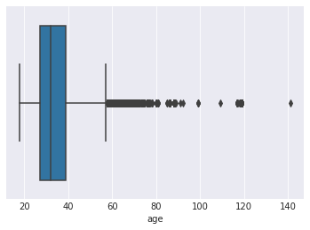

```python
sb.boxplot(data = bike_clean, x = 'age')
```

From both the programmatica and visual assesments above, we can see that the majority of the distrbution is between the 18 and 39 ages with a lot of outliers coming in above the age 60 mark. We can therfore filter out ages 70 and above to get a more representative dataset.

```python
age = bike_clean[bike_clean.age < 70]
```

```python
#check for new max and min age values
age.describe()
```

|  | duration_sec | member_birth_year | duration_minute | age |
| --- | --- | --- | --- | --- |
| count | 174278.000000 | 174278.000000 | 174278.000000 | 174278.000000 |
| mean | 704.255936 | 1984.981552 | 11.737599 | 34.018448 |
| std | 1644.655261 | 9.679385 | 27.410921 | 9.679385 |
| min | 61.000000 | 1950.000000 | 1.016667 | 18.000000 |
| 25% | 323.000000 | 1980.000000 | 5.383333 | 27.000000 |
| 50% | 511.000000 | 1987.000000 | 8.516667 | 32.000000 |
| 75% | 789.000000 | 1992.000000 | 13.150000 | 39.000000 |
| max | 84548.000000 | 2001.000000 | 1409.133333 | 69.000000 |

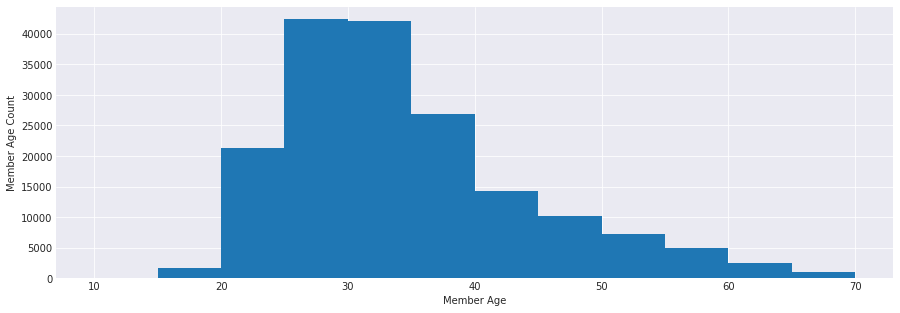

```python
#plotting the histogram
plt.figure(figsize = [15,5])
bins = np.arange(10, age['age'].max()+5, 5)
plt.hist(data=bike_clean, x='age', bins=bins);
plt.xlabel('Member Age');
plt.ylabel('Member Age Count');
```

The above chart shows that the majority of the distribution falls mainly between the ages of 20 and 40, which further corroborates the earlier assertions of the bike rides being commutes to and from work sice a lot of the work force falls between that age range.

### What is the most common trip duration?

```python
bike_clean.duration_minute.describe(percentiles = [.99])
```

```
count    174952.000000
mean         11.733379
std          27.370082
min           1.016667
50%           8.500000
99%          52.933333
max        1409.133333
Name: duration_minute, dtype: float64
```

The above shows that most bike rides are between 1 minute and 53 minutes, so we can plot our histogram in this range to get a better look at the distribution. We can also filter out the remainig outliers from the trip duration column.

```python
bike_clean = bike_clean[bike_clean.duration_minute < 60]
bike_clean.duration_minute.describe()
```

```
count    173566.000000
mean         10.308359
std           7.396235
min           1.016667
25%           5.350000
50%           8.450000
75%          13.000000
max          59.933333
Name: duration_minute, dtype: float64
```

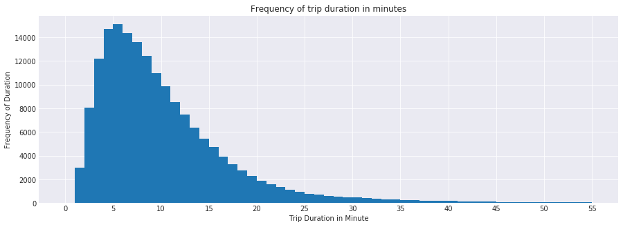

```python
plt.figure(figsize = [15,5])
bins = np.arange(0, 55+1, 1)
ticks = np.arange(0, 55+5, 5)
plt.hist(data=bike_clean, x='duration_minute',bins = bins);
plt.xticks(ticks,ticks)
plt.xlabel('Trip Duration in Minute');
plt.ylabel("Frequency of Duration");
plt.title('Frequency of trip duration in minutes');
```

The distribution peaks at about 6 minutes, with most of the trip duration falling between 5 and 20 minutes.

### Discuss the distribution(s) of your variable(s) of interest. Were there any unusual points? Did you need to perform any transformations?

> For the time related columns , I noticed that the most bike rides occured during the weekdays with a dip on weekends. The most common times during the week which had the most bike rides were the 08:00 and 17:00 hours which conicides wit the time people mostly leave for work and return home from work. Most bike rides lasted mostly beteen 5 and 20 minutes. For the user related columns, I found out most people who use the bike sharing service were males and most of the users fell between the ages of 20 and 40. Most users didn't take up the bike sharing option and preferred to ride alone. Most users were also people who are subscribed to the service as opposed to the casual users.

### Of the features you investigated, were there any unusual distributions? Did you perform any operations on the data to tidy, adjust, or change the form of the data? If so, why did you do this?

> There weren't any unsual distributions because i filtered out all the outliers within the age and the duration minute columns to help have a clearer and more representative view of the distribution.

## Bivariate Exploration

### What is the relationship between gender and the trip duration in minutes?

```python
#setting figure size for plots below
plt.rcParams['figure.figsize'] = 10, 6
```

```python
#filtering for just male and female genders
genders_new = bike_clean.copy()
genders_new['member_gender'] = genders_new['member_gender'].astype(str)
genders_new = genders_new[genders_new['member_gender'].isin(['Male','Female'])].copy()
```

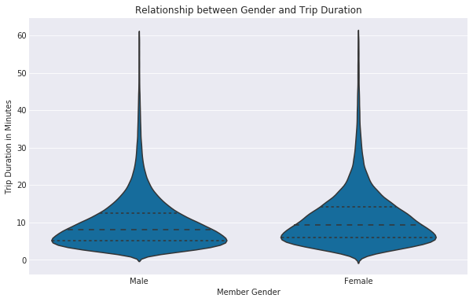

```python
sb.violinplot(data = genders_new, x = 'member_gender', y = 'duration_minute',inner = 'quartile',color = color)
plt.xlabel('Member Gender')
plt.ylabel("Trip Duration in Minutes")
plt.title("Relationship between Gender and Trip Duration");
```

Female members tend to spend a slightly higher time during trips than the male members. The median time used by female members is about ten minutes whiole that of the male members is about 8 minutes.

### What is the relationship between customer type and the trip duration in minutes?

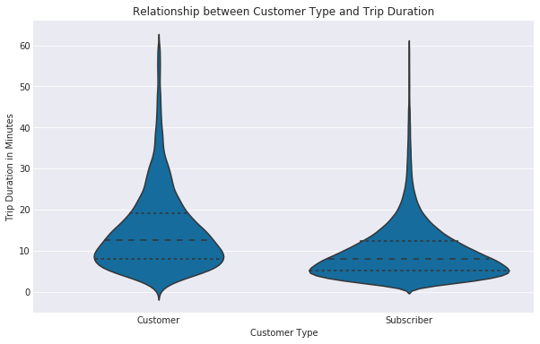

```python
sb.violinplot(data = bike_clean, x = 'user_type', y = 'duration_minute',inner = 'quartile',color = color)
plt.xlabel('Customer Type')
plt.ylabel("Trip Duration in Minutes")
plt.title("Relationship between Customer Type and Trip Duration");
```

Subscribers tend to have less trip duration times than the casual customers. This might mean that subscribers have targeted use of the bike sharing service like commuting to work, while the casual customers use the service at their whim.

### What is the average duration trip on each day of the week?

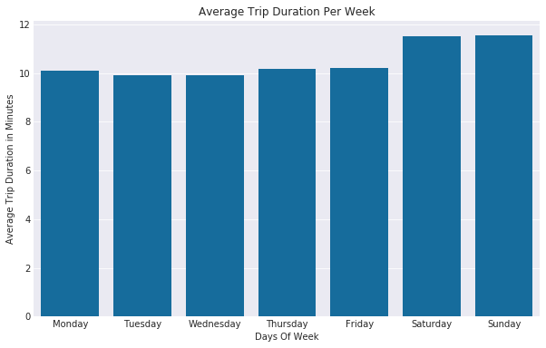

```python
sb.barplot(data = bike_clean, x = 'start_dayofweek', y = 'duration_minute', order = orderbyDayOfWeek, color = color, ci = None)
plt.xlabel('Days Of Week');
plt.ylabel('Average Trip Duration in Minutes')
plt.title("Average Trip Duration Per Week");
```

The barplot above shows an almost uniform average trip duration during the weekdays with an icrease in the trip duration on the weekends. This shows that weekday trips by the users are mostly planned always occuring trips.

### How often do the different customer types use the service weekly?

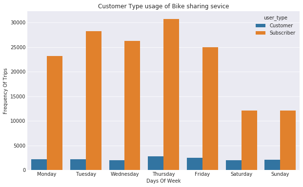

```python
sb.countplot(data = bike_clean, x ='start_dayofweek', hue = 'user_type', order = orderbyDayOfWeek )
plt.xlabel('Days Of Week')
plt.ylabel("Frequency Of Trips")
plt.title("Customer Type usage of Bike sharing sevice");
```

The plot above shows that the subscribers mostly used the service on weekdays with the peak amount of trips coming on Thursdays. There is a decline in the amount of trips for the subscribers heading into the weekend because as we have hypothesised before, the subscribers mostly used the bike sharing service as commutes to and from work.

### What is the relationship between the age and the trip duration?

```python
age = age.query('duration_minute < 60')
age = age.query('member_gender != "Other"')
```

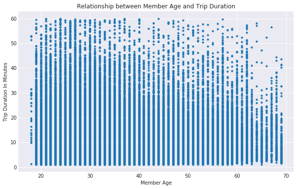

```python
plt.scatter(data = age, x = 'age', y = 'duration_minute', s = 10)
plt.xlabel('Member Age')
plt.ylabel('Trip Duration In Minutes')
plt.title("Relationship between Member Age and Trip Duration");
```

From theplot above, a lot of the distribution is between the ages 20 and 40 range, and the most trip duration minutes were within the between that age range which isn't that suprising.

### What is the relationship between the Age and the Customer type?

```
Text(0.5,1,'Relationship between the Age and the Customer type')
```

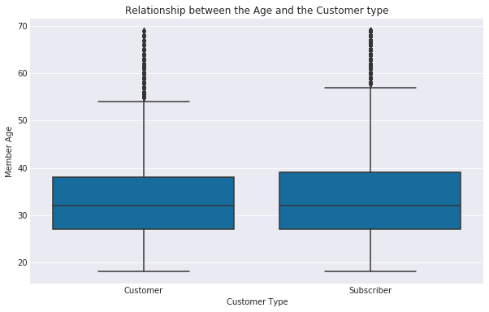

```python
sb.boxplot(data=age, x='user_type', y='age', color=color);
plt.xlabel('Customer Type');
plt.ylabel('Member Age');
plt.title("Relationship between the Age and the Customer type")
```

A higher distribution of the subcribers tend to be slightly older than the casual customers. This might explain the reason subscribers tend to take shorter trips as observed in one of the violin plots above.

### What is the relationship between the Age and the Member Gender?

```python
#filtering out the outlier ages from the new gender dataframe(just male and female)
genders_new = genders_new.query('age < 70')
```

```
Text(0.5,1,'Relationship between the Age and the Member Gender')
```

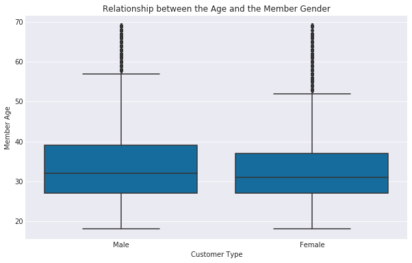

```python
sb.boxplot(data=genders_new, x='member_gender', y='age', color=color);
plt.xlabel('Customer Type');
plt.ylabel('Member Age');
plt.title("Relationship between the Age and the Member Gender")
```

A higher distribution of the male members tend to be older than the female members. This might explain the reason female members average longer trip durations than the make members

### Talk about some of the relationships you observed in this part of the investigation. How did the feature(s) of interest vary with other features in the dataset?

> I found out that female riders have a slightly higher trip duration time than their male counterparts. Also, subcribers have a smaller trip dration time as compared to the casual users of the service. Average trips on the weekdays are of a smaller proportion as compared to the weekend trip durations. Subscribers take way more trips than the casual customers. The comparison between member age and trip duration shows that younger members tend to take longer trips.

### Did you observe any interesting relationships between the other features (not the main feature(s) of interest)?

> It was a bit suprising to find out that the female subscribers take longer trips on the average than male subsccribers

## Multivariate Exploration

### What is the relationship between the age and trip duration with respect to the gender?

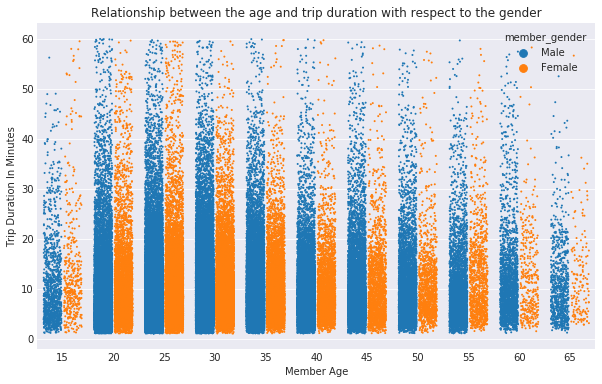

```python
#create a categorical version of age, every 5 years using floor division //
genders_new['age_cat'] = ((genders_new['age']//5)*5)
sb.stripplot(data = genders_new,x = 'age_cat', y = 'duration_minute',hue = 'member_gender',jitter = 0.35, dodge = True, size =2)
plt.xlabel('Member Age')
plt.ylabel('Trip Duration In Minutes');
plt.title('Relationship between the age and trip duration with respect to the gender');
```

The strip plots show that for both the amle and female subscribers, the members from ages 20-40 are the ones with the highest trip durations while it decreases from that age onwards.

### What is the average trip duration on weekdays with respect to Customer type?

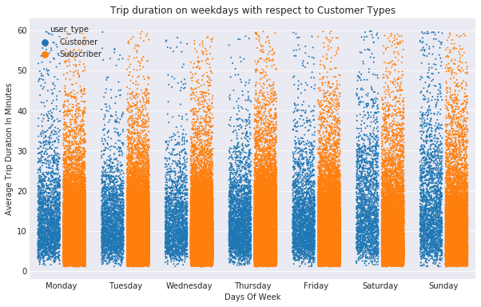

```python
sb.stripplot(data = genders_new, x = 'start_dayofweek', y = 'duration_minute',hue = 'user_type',order = orderbyDayOfWeek,
            jitter = 0.35, dodge = True, size =2)
plt.xlabel('Days Of Week')
plt.ylabel("Average Trip Duration In Minutes");
plt.title('Trip duration on weekdays with respect to Customer Types');
```

### What is the average trip duration on weekdays with respect to gender?

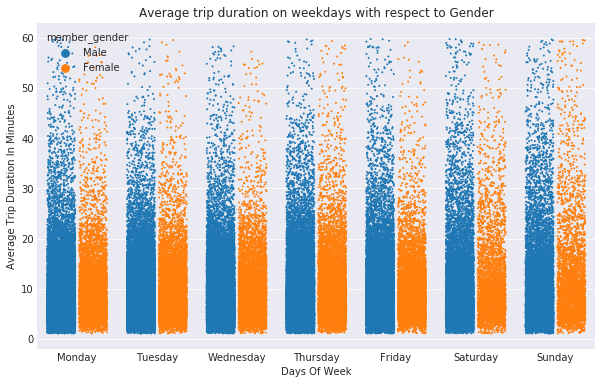

```python
sb.stripplot(data = genders_new, x = 'start_dayofweek', y = 'duration_minute',hue = 'member_gender',order = orderbyDayOfWeek,
          jitter = 0.35, dodge = True, size =2)
plt.xlabel('Days Of Week')
plt.ylabel("Average Trip Duration In Minutes");
plt.title('Average trip duration on weekdays with respect to Gender');
```

### Talk about some of the relationships you observed in this part of the investigation. Were there features that strengthened each other in terms of looking at your feature(s) of interest?

> During the multivariate exploration, some of my earlier assertions were validated such as the female subcribers averaging higher trip durations than their male counterparts. Also I was able to confirm that the the casual customers averge a higher trip duration time than the subscribers.

## Conclusions

> In the exploration, I found that the most bike rides occured during the weekdays with a dip on weekends. The most common times during the week which had the most bike rides were the 08:00 and 17:00 hours which conicides wit the time people mostly leave for work and return home from work. I found that most of the bike rides were between 5 and 20 minutes, most of the members of the service were male, and the most common ages were between 20 and 40. The subscribers outnumber the casual customers, and most of the members of the service did not exercise the bike sharing option often, instead opting to ride alone. Female members tend to have a slightly higher trip durations than the male members, casual users also have higher trip duration times than subscribers. Average trip minutes during the weekdays were almost uniform with an increase during the weekends, members between the age range of 20-40 average higher trip minutes and the trip minutes decrease as the age increases.